# Machine Learning for Problem Solving(Spring 2018)

Anupam Dewan(adewan)

### Question 5: Exploraratory Data Analysis and KDE

# 5.1 Summary Statistics and what are meaningless qunantities?

|  | EmployeeID | recorddate_key | birthdate_key | orighiredate_key | terminationdate_key | age | length_of_service | city_name | department_name | job_title | store_name | gender_short | gender_full | termreason_desc | termtype_desc | STATUS_YEAR | STATUS | BUSINESS_UNIT |
| --- | --- | --- | --- | --- | --- | --- | --- | --- | --- | --- | --- | --- | --- | --- | --- | --- | --- | --- |
|  | Min. :1318 | 12/31/2013 0:00: 5215 | 1954-08-04: 40 | 1992-08-09: 50 | 1900-01-01:42450 | Min. :19.00 | Min. : 0.00 | Vancouver :11211 | Meats :10269 | Meat Cutter :9984 | Min. : 1.0 | F:25898 | Female:25898 | Layoff : 1705 | Involuntary : 1705 | Min. :2006 | ACTIVE :48168 | HEADOFFICE: 585 |
|  | 1st Qu.:3360 | 12/31/2012 0:00: 5101 | 1956-04-27: 40 | 1995-02-22: 50 | 2014-12-30: 1079 | 1st Qu.:31.00 | 1st Qu.: 5.00 | Victoria : 4885 | Dairy : 8599 | Dairy Person :8590 | 1st Qu.:16.0 | M:23755 | Male :23755 | Not Applicable:41853 | Not Applicable:41853 | 1st Qu.:2008 | TERMINATED: 1485 | STORES :49068 |
|  | Median :5031 | 12/31/2011 0:00: 4972 | 1973-03-23: 40 | 2004-12-04: 50 | 2015-12-30: 674 | Median :42.00 | Median :10.00 | Nanaimo : 3876 | Produce : 8515 | Produce Clerk:8237 | Median :28.0 | NA | NA | Resignaton : 2111 | Voluntary : 6095 | Median :2011 | NA | NA |
|  | Mean :4859 | 12/31/2014 0:00: 4962 | 1952-01-27: 30 | 2005-10-16: 50 | 2010-12-30: 25 | Mean :42.08 | Mean :10.43 | New Westminster: 3211 | Bakery : 8381 | Baker :8096 | Mean :27.3 | NA | NA | Retirement : 3984 | NA | Mean :2011 | NA | NA |
|  | 3rd Qu.:6335 | 12/31/2010 0:00: 4840 | 1952-08-10: 30 | 2006-02-26: 50 | 2012-11-11: 21 | 3rd Qu.:53.00 | 3rd Qu.:15.00 | Kelowna : 2513 | Customer Service: 7122 | Cashier :6816 | 3rd Qu.:42.0 | NA | NA | NA | NA | 3rd Qu.:2013 | NA | NA |
|  | Max. :8336 | 12/31/2015 0:00: 4799 | 1953-10-06: 30 | 2006-09-25: 50 | 2015-02-04: 20 | Max. :65.00 | Max. :26.00 | Burnaby : 2067 | Processed Foods : 5911 | Shelf Stocker:5622 | Max. :46.0 | NA | NA | NA | NA | Max. :2015 | NA | NA |
|  | NA | (Other) :19764 | (Other) :49443 | (Other) :49353 | (Other) : 5384 | NA | NA | (Other) :21890 | (Other) : 856 | (Other) :2308 | NA | NA | NA | NA | NA | NA | NA | NA |

According to summary statistics it seems that Gender_full and Gender_Short represent the same thing (one says “M” and Males which essentially means the same) and therefore we eleminate one of them.(eliminated Gender_full)

# 5.2 The percentage of terminated employees out of all employees for each year and Average termination rate in 10 years

| STATUS_YEAR | percentage |
| --- | --- |
| 2006 | 2.926403 |
| 2007 | 3.459321 |
| 2008 | 3.440319 |
| 2009 | 2.926628 |
| 2010 | 2.478340 |
| 2011 | 2.164502 |
| 2012 | 2.485184 |
| 2013 | 1.973684 |
| 2014 | 4.851390 |
| 2015 | 3.265471 |

| 2.997124 |
| --- |

# 5.3 A stacked bar chart of terminates.

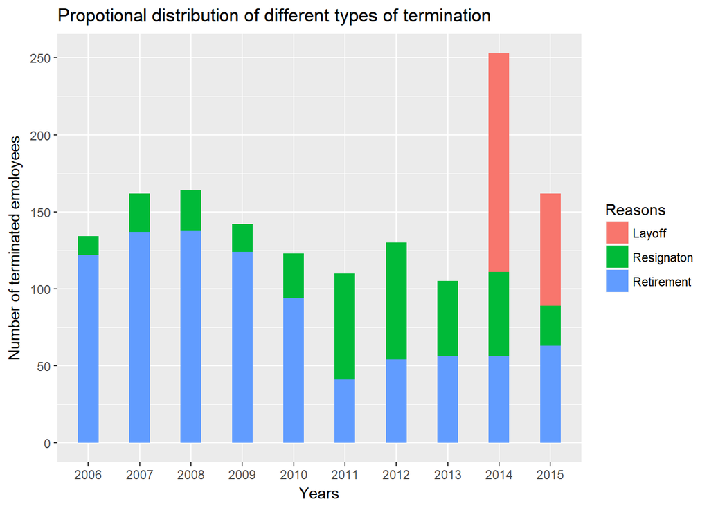

Interpretation: Majorly from 2006-2010 there was no layoff per se, and the major contribution of termination of employee service was due to the retirement. From 2010-2013 the distribution started to spread out evenly and almost similar percentage of employees were terminating due to either of the two reasons. Post 2013, company has started to lay off its employees which has then become one of the major reasons for employee service terminations.

# 5.4 :Does Age affect termination?

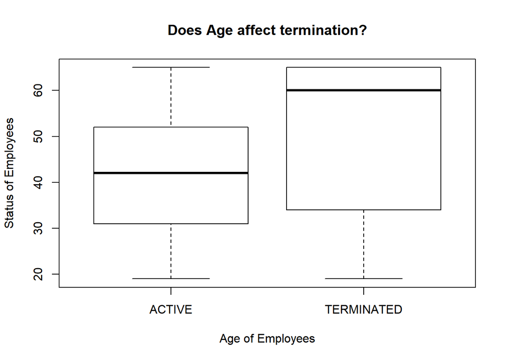

Interpretation: Seeing the box plot we can say that the median age of employees whose status is active is around 40 whereas the ones which have been terminated have an average age of 60. This shows that higher ages leads to termination more often.Therfore, we can say that Age is an important factor in termination.

# 5.5 Does Length of Service affect termination?

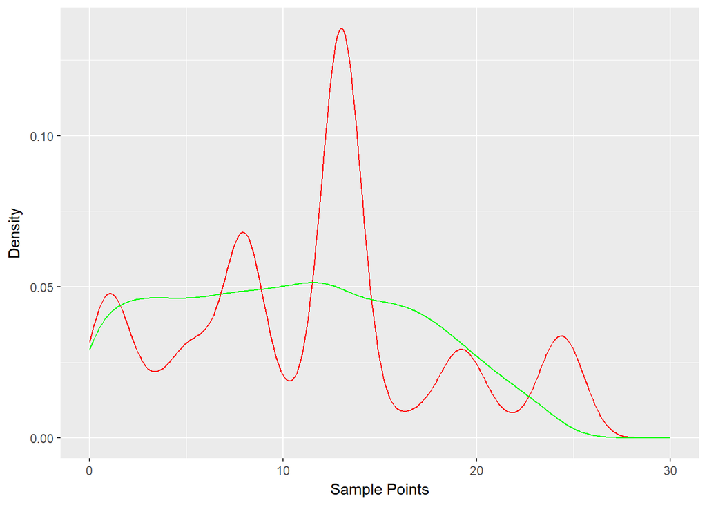

```r
gauss <- function(x) {
  y <-1/sqrt(2*pi) * exp(-(x^2)/2)
  return(y)
}
kde_func<-function(x,status){
  col<-c()
  stat <-dplyr::filter(new_terminations,STATUS==status)
  obv_len <- dplyr::select(stat,length_of_service)
  for (j in  obv_len){
      diff<-x-j
      density_estimates <-gauss(diff)
      col<-c(col,density_estimates)
      diff<-0
      density_estimates<-0
  }
  summ<-sum(col)
  est<-summ/nrow(obv_len)
  return(est)
}
  x<-sample(seq(0,30,0.1))
  active_col<-c()
  term_col<-c()
  for(i in x){
    active_col<-c(active_col,kde_func(i,"ACTIVE"))
    term_col<-c(term_col,kde_func(i,"TERMINATED"))
  }
  active_df<-data.frame(active_col)
  term_df<-data.frame(term_col)
  df<-cbind(active_df,term_df)
  ggplot(df, aes(x)) +
  geom_line(aes(y=term_col), colour="red") +
  geom_line(aes(y=active_col), colour="green")+
  xlab("Sample Points")+ylab("Density")
```

Interpretation: It can be deduced that the red line(terminated employees) has more bumps which menas that length of service sees alot of variation among terminated employees

### Question 6: Applied Linear Regression

# 6.1: Regressing wage on age:

|  | Estimate | Std. Error | t value | Pr(>\|t\|) |
| --- | --- | --- | --- | --- |
| (Intercept) | 81.7047354 | 2.8462422 | 28.70618 | 0 |
| age | 0.7072759 | 0.0647511 | 10.92299 | 0 |

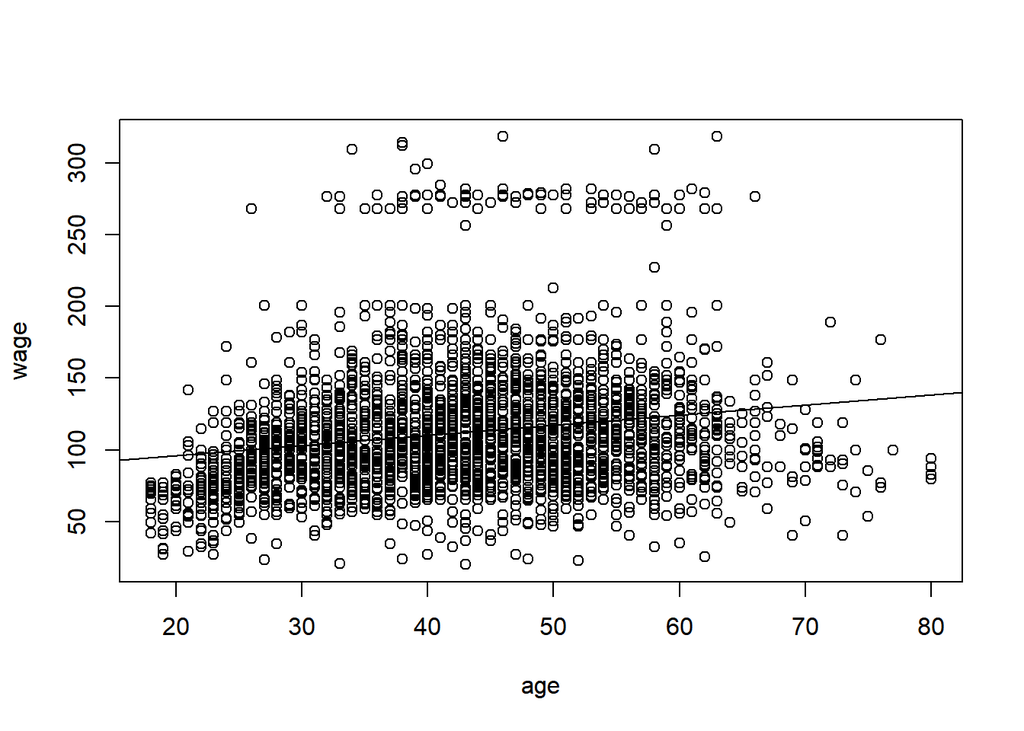

# 6.2:Regressing Wage on age,jobclass,interraction of job class and age

|  | Estimate | Std. Error | t value | Pr(>\|t\|) |
| --- | --- | --- | --- | --- |
| (Intercept) | 73.5283101 | 3.7613315 | 19.548479 | 0.0000000 |
| age | 0.7196626 | 0.0874392 | 8.230438 | 0.0000000 |
| jobclass2. Information | 22.7308551 | 5.6314068 | 4.036443 | 0.0000556 |
| age:jobclass2. Information | -0.1601733 | 0.1278514 | -1.252808 | 0.2103733 |

# 6.3:Regressing wage on 4th degree polynomial of age:

|  | Estimate | Std. Error | t value | Pr(>\|t\|) |
| --- | --- | --- | --- | --- |
| (Intercept) | 108.0365847 | 1.0541486 | 102.48705 | 0e+00 |
| I(age^4) | 0.0000008 | 0.0000002 | 5.01142 | 6e-07 |

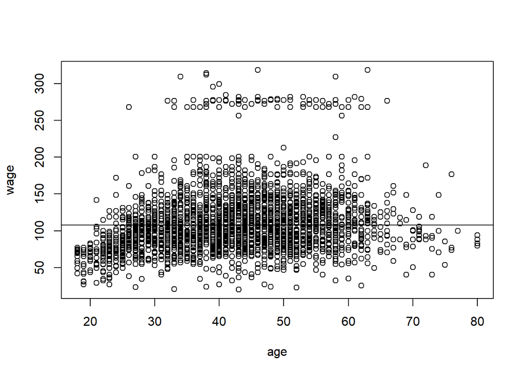

# 6.4:Regressing wage with all parameters

|  | Estimate | Std. Error | t value | Pr(>\|t\|) |
| --- | --- | --- | --- | --- |
| (Intercept) | -7753.9878320 | 3.527567e+03 | -2.1981120 | 0.0280205 |
| year | 3.9064463 | 1.759254e+00 | 2.2205127 | 0.0264616 |
| age | 105.1818000 | 6.209706e+01 | 1.6938289 | 0.0904060 |
| maritl2. Married | -1954.8294255 | 1.718873e+03 | -1.1372741 | 0.2555184 |
| maritl3. Widowed | -2403.9842513 | 2.239426e+04 | -0.1073482 | 0.9145202 |
| maritl4. Divorced | -1577.1764114 | 2.967512e+03 | -0.5314811 | 0.5951264 |
| maritl5. Separated | -1239.2926357 | 4.965046e+03 | -0.2496034 | 0.8029118 |
| race2. Black | -446.9239880 | 2.263837e+03 | -0.1974188 | 0.8435138 |
| race3. Asian | 5305.8656618 | 2.507827e+03 | 2.1157225 | 0.0344541 |
| race4. Other | 4704.0871022 | 6.004561e+03 | 0.7834190 | 0.4334456 |
| education2. HS Grad | -194.1489520 | 2.340968e+03 | -0.0829353 | 0.9339087 |
| education3. Some College | 1357.6269422 | 2.506166e+03 | 0.5417148 | 0.5880569 |
| education4. College Grad | 1470.3987000 | 2.517487e+03 | 0.5840740 | 0.5592163 |
| education5. Advanced Degree | -2806.4464414 | 2.766035e+03 | -1.0146099 | 0.3103771 |
| jobclass2. Information | -917.9961304 | 1.327927e+03 | -0.6913000 | 0.4894328 |
| health2. >=Very Good | 1950.9107872 | 1.440992e+03 | 1.3538665 | 0.1758853 |
| health_ins2. No | 2117.1199039 | 1.398057e+03 | 1.5143300 | 0.1300519 |
| year:age | -0.0524606 | 3.095740e-02 | -1.6946057 | 0.0902584 |
| year:maritl2. Married | 0.9867612 | 8.570900e-01 | 1.1512924 | 0.2497076 |
| year:maritl3. Widowed | 1.1776423 | 1.113896e+01 | 0.1057228 | 0.9158096 |
| year:maritl4. Divorced | 0.8014230 | 1.479802e+00 | 0.5415743 | 0.5881537 |
| year:maritl5. Separated | 0.6193224 | 2.474723e+00 | 0.2502593 | 0.8024047 |
| year:race2. Black | 0.2252702 | 1.129206e+00 | 0.1994944 | 0.8418902 |
| year:race3. Asian | -2.6474321 | 1.251165e+00 | -2.1159742 | 0.0344326 |
| year:race4. Other | -2.3425831 | 2.992688e+00 | -0.7827689 | 0.4338272 |
| year:education2. HS Grad | 0.0978807 | 1.167770e+00 | 0.0838185 | 0.9332066 |
| year:education3. Some College | -0.6810055 | 1.250115e+00 | -0.5447543 | 0.5859647 |
| year:education4. College Grad | -0.7239778 | 1.255845e+00 | -0.5764866 | 0.5643314 |
| year:education5. Advanced Degree | 1.4014164 | 1.379568e+00 | 1.0158372 | 0.3097923 |
| year:jobclass2. Information | 0.4598472 | 6.621812e-01 | 0.6944432 | 0.4874604 |

[output cut: 91 more lines]

# 6.5 Lasso Regression and Comparision between coeffecients

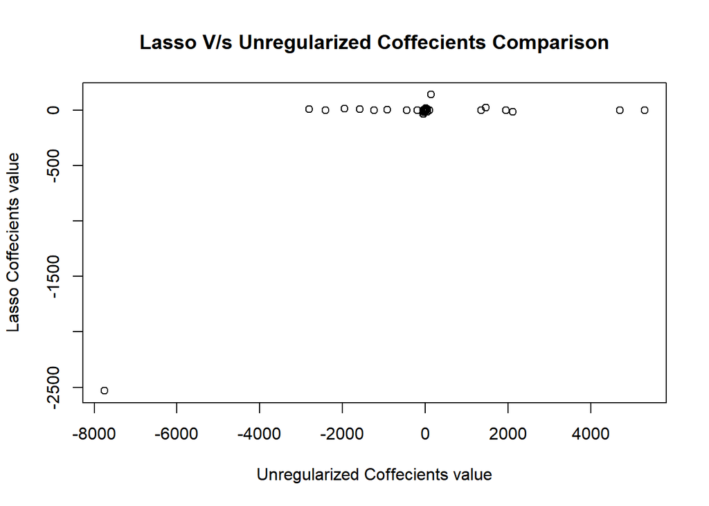

Interpretation: We can observe from the sctter plot that many lasso and unregularized coffecient values match at lower values around 0 (that is why it has a darker black dot at 0).Moreover, we find that Lasso coffecients values are generally surrounded at or around 0, because now the coffecient value get regularized and useless variebles are penalized to reduction in coffeceint values.

(Discussed with Karuna Saproo)